# Diversity project actual analyses I swear

2026-02-04

We will finally analyse this data properly. This script makes plots for figures 3 and 4 (possibly now only a single figure), and most of the statistical analyses that underpin them, as well as most of the numbers describing the SRA data in the text.

After discussion with Amanda, we’ll be using the strictestRace/Geography assignments, see `06_revisiting_population_terms` for more context on what this means.

```r
# Read in, and tabulate sample origin:
allSRAFinal <- readRDS("20250517_allSRAFinalRazi.rds")
sourceRepo <- allSRAFinal %>% mutate(
  repo = ifelse(grepl("^SR", SRA.Study), "SRA", ifelse(grepl("^ER", SRA.Study), "ENA", "DRA"))) %>%
  count(repo)
sourceRepo
```

```
##   repo     n
## 1  DRA    78
## 2  ENA  1672
## 3  SRA 22185
```

```r
sum(sourceRepo$n) # This is still not the right subset...
```

```
## [1] 23935
```

```r
# The original numbers were:
sourceRaw <- data.frame(repo = c("DRA", "ENA", "SRA"), n = c(10384, 68190, 716497))
sourceRepo$n/sourceRaw$n
```

```
## [1] 0.007511556 0.024519724 0.030963144
```

```r
studyRaw <- data.frame(repo = c("DRA", "ENA", "SRA"), n = c(195, 1230, 19784))

# First we clean up the plotting labels:
allSRAFinal <- allSRAFinal %>%
    mutate(strictestRace = gsub("or ", "or\n", strictestRace)) %>%
    mutate(strictestGeography = gsub("and ", "and\n", strictestGeography)) %>%
    mutate(strictestGeography = gsub("^Asia$", "Asia (NOS)", strictestGeography)) %>%
    mutate(strictestGeography = gsub("Subsaharan", "Sub-Saharan", strictestGeography)) %>%
    mutate(hispanic = gsub("^hispanic$", "Hispanic", hispanic)) %>%
    mutate(finalOrgan = gsub("^cancer$", "Cancer sample\n(NOS)", finalOrgan)) %>%
    mutate(finalSystem = gsub("^cancer$", "Cancer sample\n(NOS)", finalSystem)) %>%
    as.data.frame()

# For moving columns to upper case, because I forgot...
firstup <- function(x) {
  substr(x, 1, 1) <- toupper(substr(x, 1, 1))
  x
}

allSRAFinal$finalDisease <- firstup(allSRAFinal$finalDisease)
allSRAFinal$finalOrgan <- firstup(allSRAFinal$finalOrgan)
allSRAFinal$finalSystem <- firstup(allSRAFinal$finalSystem)

# Hispanic label trumps any other label
allSRAFinal$backupRace <- allSRAFinal$strictestRace
allSRAFinal$backupHispanic <- allSRAFinal$hispanic
allSRAFinal <- allSRAFinal %>% mutate(hispanic = na_if(hispanic, "non.hispanic"))
allSRAFinal$strictestRace <- coalesce(allSRAFinal$hispanic, allSRAFinal$strictestRace)
allSRAFinal$strictestRace <- factor(allSRAFinal$strictestRace)

# Now let's sort out some colour schemes... For Race we simply use Dark2 but we need to keep the mapping consistent, but for Geography we are following Alicia Martin and using a somewhat custom palette that doesn't follow anything standard, and then adding some new colours of our own; I opened a paper in Affinity and grabbed the html values and then added a couple for the new entries (Southeast Asia, Asia NOS):

allSRAFinal$strictestGeography <- factor(allSRAFinal$strictestGeography, levels = c("Sub-Saharan Africa", "North Africa and\nWestern Asia", "Europe", "South Asia", "Southeast Asia", "East Asia", "Asia (NOS)", "Oceania", "Americas", "Multiple", "Other"))

scale_fill_geography <- function(...){
    ggplot2:::manual_scale('fill',
        values = setNames(c('#9C8DC3', '#F3D78A', '#DB6968', '#60BC55', '#BCCC45', '#4D97CD', '#04C3C8', '#C69C3A', '#F8984E', '#8B96AD', '#FBC9C4'), levels(allSRAFinal$strictestGeography)),
    )
}

scale_color_geography <- function(...){
    ggplot2:::manual_scale('color',
        values = setNames(c('#9C8DC3', '#F3D78A', '#DB6968', '#60BC55', '#BCCC45', '#4D97CD', '#04C3C8', '#C69C3A', '#F8984E', '#8B96AD', '#FBC9C4'), levels(allSRAFinal$strictestGeography)),
    )
}

raceColours <- brewer.pal(8,"Set2") #8 because we don't plot NAs

scale_color_race <- function(...){
    ggplot2:::manual_scale('color',
                           values = setNames(raceColours, levels(allSRAFinal$strictestRace)),
    )
}

scale_fill_race <- function(...){
    ggplot2:::manual_scale('fill',
        values = setNames(raceColours, levels(allSRAFinal$strictestRace)),
    )
}

wberCols <- c(viridis::turbo(n = 7))
scale_fill_wber <- function(...){
    ggplot2:::manual_scale('fill',
        values = setNames(wberCols, c("East Asia &\nPacific", "Europe &\nCentral Asia", "Latin America &\nCaribbean", "Middle East &\nNorth Africa", "North America", "South Asia", "Sub-Saharan Africa")), na.value = "grey50")
}


# We also define a couple of plot layouts:
long2Design <- "
  12
  12
"
wide2Design <- "
  11
  22
"

twox2DesignRowWise <- "
  12
  34
"

twox2DesignColWise <- "
  13
  24
"


theme_set(theme_bw(base_size = 6))
theme_update(axis.text=element_text(size=7))
theme_update(legend.key.size = unit(12, 'pt'), #change legend key size
        legend.title = element_text(size=8), #change legend title font size
        legend.text = element_text(size=6),
        plot.title = element_text(size=8))
theme_update(plot.margin = unit(c(0, 0, 0, 0), "pt"))
```

We’re also going to use some additional info from the World Bank, so let’s add those columns in now:

```r
worldBank <- read.csv("World_Bank_Descriptors.csv")

# Some names need to be fixed, but others are more flexible? I'd rather have USA than United States.
allSRAFinal$finalCountry <- gsub("^UK$", "United Kingdom", allSRAFinal$finalCountry)
allSRAFinal$finalCountry <- gsub("^Korea$", "South Korea", allSRAFinal$finalCountry)

allSRAFinal$worldBank <- worldBank[match(allSRAFinal$finalCountry, worldBank$Economy),]$Income.group
# allSRAFinal %>% count(finalCountry, worldBank)

# Missing countries are all high income, so we can set them to that manually now that we're happy with the names:
allSRAFinal <- allSRAFinal %>%
  mutate(worldBank = if_else(is.na(worldBank), "High income", worldBank)) %>%
  mutate(worldBank = if_else(is.na(finalCountry), NA, worldBank ))

# And now the regions they define:
allSRAFinal$worldRegion <- worldBank[match(allSRAFinal$finalCountry, worldBank$Economy),]$Region
# allSRAFinal %>% count(finalCountry, worldRegion)

# Once again we gotta add some manually...
allSRAFinal <- allSRAFinal %>%
  mutate(worldRegion = if_else(grepl("Russia|Slovakia", finalCountry), "Europe & Central Asia", worldRegion)) %>%
  mutate(worldRegion = if_else(grepl("South Korea|Taiwan", finalCountry), "East Asia & Pacific", worldRegion)) %>%
  mutate(worldRegion = if_else(grepl("USA", finalCountry), "North America", worldRegion)) %>%
  as.data.frame()

# And now we need to clean up some labels so we can plot them better. Good thing is, it's just an ampersand:
allSRAFinal$worldRegion <- gsub("& ", "&\n", allSRAFinal$worldRegion)
```

## 1. Who is being sequenced?

```r
geographyProp <- allSRAFinal %>% drop_na(strictestGeography) %>% count(strictestGeography) %>% mutate(freq = n/sum(n))
raceProp <- allSRAFinal %>% drop_na(strictestRace) %>% count(strictestRace) %>% mutate(freq = n/sum(n))

geoPlot <- ggplot(geographyProp, aes(x = fct_inorder(strictestGeography), y = n, fill = strictestGeography)) +
  geom_bar(stat="identity") +
  ggtitle("Submitted descriptor\n(ancestral/geographic origin)") +
  xlab("") +
  ylab("Samples") +
  coord_flip() +
  scale_fill_geography() +
  theme(axis.text.x = element_text(angle = 45, hjust=1)) +
  theme(legend.position="none")

geographyProp
```

```
##                strictestGeography    n        freq
## 1              Sub-Saharan Africa 1687 0.172090176
## 2  North Africa and\nWestern Asia   18 0.001836173
## 3                          Europe 5451 0.556054269
## 4                      South Asia  718 0.073242885
## 5                  Southeast Asia   49 0.004998470
## 6                       East Asia 1114 0.113638682
## 7                      Asia (NOS)  306 0.031214934
## 8                         Oceania   11 0.001122105
## 9                        Americas  180 0.018361726
## 10                       Multiple  207 0.021115985
## 11                          Other   62 0.006324595
```

```r
sum(geographyProp$n)
```

```
## [1] 9803
```

```r
racePlot <- ggplot(raceProp, aes(x = fct_inorder(strictestRace), y = n, fill=strictestRace)) +
  geom_bar(stat="identity") +
  ggtitle("Submitted descriptor\n(US Census term)") +
  xlab("") +
  ylab("Samples") +
  coord_flip() +
  scale_fill_race() +
  theme(axis.text.x = element_text(angle = 45, hjust=1)) +
  theme(legend.position="none")

raceProp
```

```
##                                 strictestRace    n         freq
## 1          American Indian and\nAlaska Native   45 0.0032142857
## 2                                       Asian  936 0.0668571429
## 3                  Black or\nAfrican American 1732 0.1237142857
## 4                                    Hispanic 1247 0.0890714286
## 5                                    Multiple  203 0.0145000000
## 6 Native Hawaiian and\nother Pacific Islander    6 0.0004285714
## 7                                       Other  162 0.0115714286
## 8                                       White 9669 0.6906428571
```

```r
sum(raceProp$n)
```

```
## [1] 14000
```

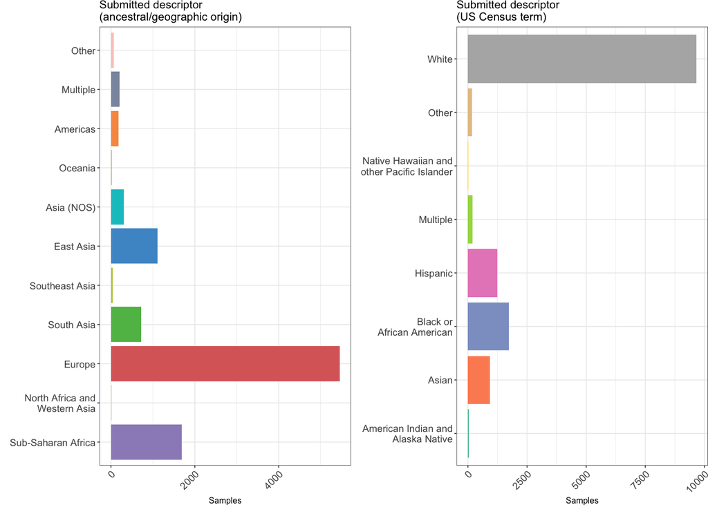

```r
geoPlot + racePlot +
    plot_layout(design = long2Design)
```

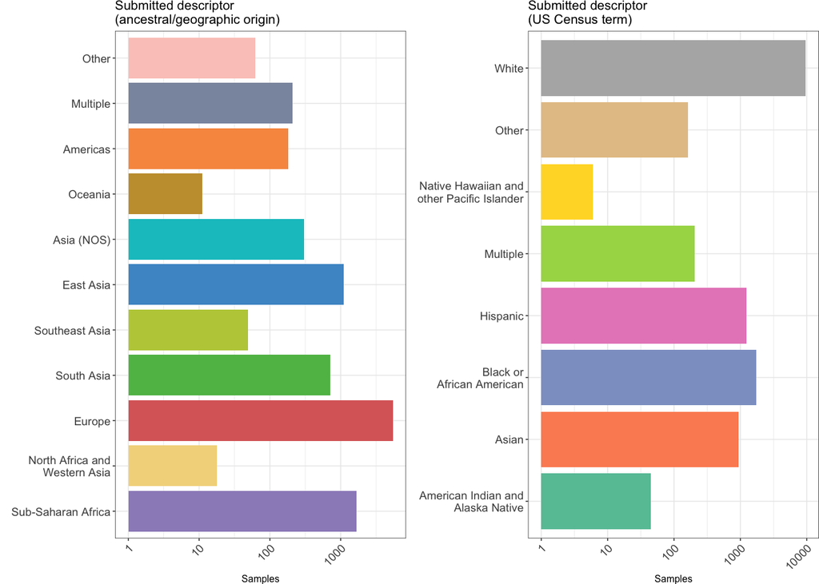

```r
# And now with log transform on the axis:
geoPlot <- geoPlot +
  scale_y_continuous(trans='log10')
racePlot <- racePlot +
  scale_y_continuous(trans='log10')

geoPlot + racePlot +
    plot_layout(design = long2Design)
```

```r
# There's 132 samples that do not have any info besides "Not Hispanic", which I think we should treat as NA, and therefore drop. The other option is to change them to race: Other and then move on with our lives.
allSRAFinal %>% filter(is.na(allSRAFinal$strictestGeography) & is.na(allSRAFinal$strictestRace)) %>% count(ETHNICITY, RACE)
```

```
##                ETHNICITY                    RACE  n
## 1           Non-Hispanic                    <NA> 36
## 2 Not Hispanic or Latino Unknown or Not Reported  4
## 3 Not Hispanic or Latino                    <NA> 92
```

```r
allSRAFinal <- allSRAFinal %>% filter(!is.na(allSRAFinal$strictestGeography) | !is.na(allSRAFinal$strictestRace))

nrow(allSRAFinal[!is.na(allSRAFinal$strictestGeography) | !is.na(allSRAFinal$strictestRace),])
```

```
## [1] 23803
```

```r
dim(allSRAFinal)
```

```
## [1] 23803    55
```

```r
# One final tally
sourceFinal <- allSRAFinal %>% mutate(
  repo = ifelse(grepl("^SR", SRA.Study), "SRA", ifelse(grepl("^ER", SRA.Study), "ENA", "DRA"))) %>%
  count(repo)
sourceFinal
```

```
##   repo     n
## 1  DRA    78
## 2  ENA  1580
## 3  SRA 22145
```

```r
sum(sourceFinal$n) # At last!
```

```
## [1] 23803
```

```r
studyFinal <- allSRAFinal %>% distinct(SRA.Study, .keep_all=T) %>%
  mutate(
    repo = ifelse(grepl("^SR", SRA.Study), "SRA", ifelse(grepl("^ER", SRA.Study), "ENA", "DRA"))) %>%
  count(repo)
studyFinal
```

```
##   repo   n
## 1  DRA   2
## 2  ENA  12
## 3  SRA 230
```

```r
sourceFinal$n/sourceRaw$n
```

```
## [1] 0.007511556 0.023170553 0.030907317
```

```r
studyFinal$n/studyRaw$n
```

```
## [1] 0.010256410 0.009756098 0.011625556
```

All samples accounted for now, at last!

So let’s get a bit more granular, showing n samples per study:

```r
sampleGeography <- allSRAFinal %>% count(SRA.Study, strictestGeography) %>% drop_na(strictestGeography)
sampleRace <- allSRAFinal %>% count(SRA.Study, strictestRace) %>% drop_na(strictestRace)
meltSampleGeography <- melt(sampleGeography)
meltSampleRace <- melt(sampleRace)
# How many studies in each category?
sampleGeography %>% distinct(SRA.Study) %>% nrow()
```

```
## [1] 127
```

```r
sampleRace %>% distinct(SRA.Study) %>% nrow()
```

```
## [1] 128
```

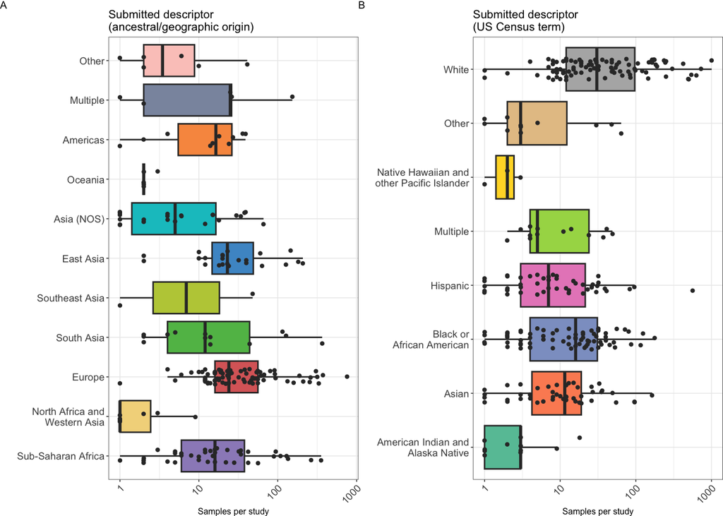

```r
geobyStudy <- ggplot(meltSampleGeography, aes(x = strictestGeography, y=value,fill=strictestGeography)) +
  geom_boxplot(width=0.8, outlier.shape = NA) +
  geom_jitter(size=0.8, width=0.2, color="#333333") +
  ggtitle("Submitted descriptor\n(ancestral/geographic origin)") +
  xlab("") +
  ylab("Samples per study") +
  coord_flip() +
  scale_y_continuous(trans='log10') +
  scale_fill_geography() +
  theme(axis.text.x = element_text(angle = 45, hjust=1)) +
  theme(legend.position = "none")

racebyStudy <- ggplot(meltSampleRace, aes(x = strictestRace, y=value,fill=strictestRace)) +
  geom_boxplot(width=0.8, outlier.shape = NA) +
  geom_jitter(size=0.8, width=0.2, color="#333333") +
  ggtitle("Submitted descriptor\n(US Census term)") +
  xlab("") +
  ylab("Samples per study") +
  coord_flip() +
  scale_y_continuous(trans='log10') +
  scale_fill_race() +
  theme(axis.text.x = element_text(angle = 45, hjust=1)) +
  theme(legend.position = "none")

geobyStudy + racebyStudy +
  plot_layout(design = long2Design) +
  plot_annotation(tag_levels = 'A')
```

```r
ggsave("fig2_by_study_boxplot.pdf", width=7, height=7)
ggsave("fig2_by_study_boxplot.png", width=7, height=7)
```

Let’s get some meaningful statistics on this:

First we separate studies on the basis of whether they contain racial or geographic descriptors. All instances of both are studies that contain both geographic and Hispanic samples.

```r
geographyClean <- allSRAFinal %>% drop_na(strictestGeography)
raceClean <- allSRAFinal %>% drop_na(strictestRace)

geoSRA <- unique(geographyClean$SRA.Study)
raceSRA <- unique(raceClean$SRA.Study)
length(intersect(geoSRA, raceSRA)) # So that's 11... and we don't love that. But last time there were 13 and we didn't do much about them...
```

```
## [1] 11
```

```r
allSRAFinal %>% filter(grepl(paste(intersect(geoSRA, raceSRA), collapse="|"), SRA.Study)) %>%
  group_by(SRA.Study) %>%
  summarise(size = n(), studyJoint = n_distinct(SRA.Study))
```

```
## # A tibble: 11 × 3
##    SRA.Study  size studyJoint
##    <chr>     <int>      <int>
##  1 DRP001797    42          1
##  2 SRP070663    12          1
##  3 SRP086245    42          1
##  4 SRP108559    32          1
##  5 SRP216947    36          1
##  6 SRP221484   195          1
##  7 SRP245400   345          1
##  8 SRP283115    17          1
##  9 SRP303641   100          1
## 10 SRP374111   100          1
## 11 SRP388678   492          1
```

```r
allSRAFinal %>% filter(grepl(paste(intersect(geoSRA, raceSRA), collapse="|"), SRA.Study)) %>% nrow()
```

```
## [1] 1413
```

```r
# So what do we do with these?
allSRAFinal %>% filter(grepl(paste(intersect(geoSRA, raceSRA), collapse="|"), SRA.Study)) %>% count(strictestGeography, strictestRace)
```

```
##               strictestGeography strictestRace   n
## 1             Sub-Saharan Africa          <NA> 323
## 2 North Africa and\nWestern Asia          <NA>  14
## 3                         Europe          <NA> 782
## 4                      East Asia          <NA>  10
## 5                     Asia (NOS)          <NA> 123
## 6                       Americas          <NA>   2
## 7                       Multiple          <NA>  28
## 8                          Other          <NA>   2
## 9                           <NA>      Hispanic 129
```

```r
# I want to see it by study, though:
allSRAFinal %>% filter(grepl(paste(intersect(geoSRA, raceSRA), collapse="|"), SRA.Study)) %>% group_by(SRA.Study) %>% count(strictestGeography, strictestRace) %>% as.data.frame()
```

```
##    SRA.Study             strictestGeography strictestRace   n
## 1  DRP001797             Sub-Saharan Africa          <NA>   8
## 2  DRP001797 North Africa and\nWestern Asia          <NA>   3
## 3  DRP001797                         Europe          <NA>  19
## 4  DRP001797                      East Asia          <NA>  10
## 5  DRP001797                           <NA>      Hispanic   2
## 6  SRP070663             Sub-Saharan Africa          <NA>   3
## 7  SRP070663                     Asia (NOS)          <NA>   6
## 8  SRP070663                           <NA>      Hispanic   3
## 9  SRP086245             Sub-Saharan Africa          <NA>  15
## 10 SRP086245                           <NA>      Hispanic  27
## 11 SRP108559             Sub-Saharan Africa          <NA>  16
## 12 SRP108559                         Europe          <NA>   8
## 13 SRP108559                           <NA>      Hispanic   8
## 14 SRP216947             Sub-Saharan Africa          <NA>   6
```

[output cut: 29 more lines]

```r
# Diversity by study:
geographyClean %>% group_by(SRA.Study) %>%
  summarise(size = n(), studyGeo = n_distinct(strictestGeography)) %>%
  summarise(n = size, meanSize = mean(size), meanGeo = mean(studyGeo), maxSize = max(size), maxGeo = max(studyGeo), sdSize = sd(size), sdGeo = sd(studyGeo))
```

```
## # A tibble: 127 × 7
##        n meanSize meanGeo maxSize maxGeo sdSize sdGeo
##    <int>    <dbl>   <dbl>   <int>  <int>  <dbl> <dbl>
##  1    40     77.2    1.69     753      6   131.  1.19
##  2   464     77.2    1.69     753      6   131.  1.19
##  3   332     77.2    1.69     753      6   131.  1.19
##  4    51     77.2    1.69     753      6   131.  1.19
##  5   133     77.2    1.69     753      6   131.  1.19
##  6    66     77.2    1.69     753      6   131.  1.19
##  7    20     77.2    1.69     753      6   131.  1.19
##  8   159     77.2    1.69     753      6   131.  1.19
##  9    44     77.2    1.69     753      6   131.  1.19
## 10   181     77.2    1.69     753      6   131.  1.19
## # ℹ 117 more rows
```

```r
raceClean %>% group_by(SRA.Study) %>%
  summarise(size = n(), studyRace = n_distinct(strictestRace)) %>%
  summarise(n = size, meanSize = mean(size), meanRace = mean(studyRace), maxSize = max(size), maxRace = max(studyRace), sdSize = sd(size), sdRace = sd(studyRace))
```

```
## # A tibble: 128 × 7
##        n meanSize meanRace maxSize maxRace sdSize sdRace
##    <int>    <dbl>    <dbl>   <int>   <int>  <dbl>  <dbl>
##  1     2     109.     2.36    1857       8   220.   1.47
##  2    36     109.     2.36    1857       8   220.   1.47
##  3    13     109.     2.36    1857       8   220.   1.47
##  4    20     109.     2.36    1857       8   220.   1.47
##  5    97     109.     2.36    1857       8   220.   1.47
##  6    37     109.     2.36    1857       8   220.   1.47
##  7    10     109.     2.36    1857       8   220.   1.47
##  8    12     109.     2.36    1857       8   220.   1.47
##  9   113     109.     2.36    1857       8   220.   1.47
## 10    50     109.     2.36    1857       8   220.   1.47
## # ℹ 118 more rows
```

```r
# And now the numbers by country:
allSRAFinal %>% drop_na(finalCountry, strictestRace) %>% count(finalCountry, strictestRace)
```

```
##      finalCountry                               strictestRace    n
## 1         Belgium                                       Asian  192
## 2         Belgium                  Black or\nAfrican American  144
## 3         Belgium                                    Hispanic  160
## 4         Belgium                                       Other  142
## 5         Belgium                                       White 1719
## 6          Canada                  Black or\nAfrican American   11
## 7          Canada                                    Hispanic   22
## 8          Canada                                       White   39
## 9           China          American Indian and\nAlaska Native    3
## 10          China                                       Asian   85
## 11          China                  Black or\nAfrican American    2
## 12          China                                       White   23
## 13        Germany                                    Hispanic    6
## 14         Israel                                       White   11
```

[output cut: 24 more lines]

```r
allSRAFinal %>% drop_na(finalCountry, strictestRace) %>% count(finalCountry, strictestRace)
```

```
##      finalCountry                               strictestRace    n
## 1         Belgium                                       Asian  192
## 2         Belgium                  Black or\nAfrican American  144
## 3         Belgium                                    Hispanic  160
## 4         Belgium                                       Other  142
## 5         Belgium                                       White 1719
## 6          Canada                  Black or\nAfrican American   11
## 7          Canada                                    Hispanic   22
## 8          Canada                                       White   39
## 9           China          American Indian and\nAlaska Native    3
## 10          China                                       Asian   85
## 11          China                  Black or\nAfrican American    2
## 12          China                                       White   23
## 13        Germany                                    Hispanic    6
## 14         Israel                                       White   11
```

[output cut: 24 more lines]

```r
# By descriptor across all studies
geographyClean %>% group_by(SRA.Study) %>% count(strictestGeography) %>% group_by(strictestGeography) %>%
  summarise(size = sum(n), studyGeo = n_distinct(SRA.Study), mean = mean(n), max = max(n), sd = sd(n))
```

```
## # A tibble: 11 × 6
##    strictestGeography                size studyGeo  mean   max      sd
##    <fct>                            <int>    <int> <dbl> <int>   <dbl>
##  1 "Sub-Saharan Africa"              1687       39 43.3    355  72.6
##  2 "North Africa and\nWestern Asia"    18        7  2.57     9   2.94
##  3 "Europe"                          5451       81 67.3    753 112.
##  4 "South Asia"                       718       13 55.2    365 102.
##  5 "Southeast Asia"                    49        2 24.5     48  33.2
##  6 "East Asia"                       1114       23 48.4    208  58.7
##  7 "Asia (NOS)"                       306       23 13.3     66  17.0
##  8 "Oceania"                           11        5  2.2      3   0.447
##  9 "Americas"                         180       10 18       39  13.5
## 10 "Multiple"                         207        5 41.4    153  63.5
## 11 "Other"                             62        6 10.3     41  15.4
```

```r
raceClean %>% group_by(SRA.Study) %>% count(strictestRace) %>% group_by(strictestRace) %>%
  summarise(size = sum(n), studyRace = n_distinct(SRA.Study), mean = mean(n), max = max(n), sd = sd(n))
```

```
## # A tibble: 8 × 6
##   strictestRace                                  size studyRace  mean   max     sd
##   <fct>                                         <int>     <int> <dbl> <int>  <dbl>
## 1 "American Indian and\nAlaska Native"             45        11  4.09    18   5.15
## 2 "Asian"                                         936        46 20.3    164  30.2
## 3 "Black or\nAfrican American"                   1732        71 24.4    177  31.3
## 4 "Hispanic"                                     1247        47 26.5    562  82.1
## 5 "Multiple"                                      203        13 15.6     49  16.5
## 6 "Native Hawaiian and\nother Pacific Islander"     6         3  2        3   1
## 7 "Other"                                         162        11 14.7     64  22.3
## 8 "White"                                        9669       100 96.7   1005 165.
```

```r
# We want a quick t-test on whether these are the same number of samples (we know they are not)

euroStudies <- geographyClean %>% filter(strictestGeography == "Europe") %>% count(SRA.Study)
oceaniaStudies <- geographyClean %>% filter(strictestGeography == "Oceania") %>% count(SRA.Study)
africaStudies <- geographyClean %>% filter(strictestGeography == "Sub-Saharan Africa") %>% count(SRA.Study)

t.test(euroStudies$n, oceaniaStudies$n)
```

```
##
##  Welch Two Sample t-test
##
## data:  euroStudies$n and oceaniaStudies$n
## t = 5.2429, df = 80.041, p-value = 1.258e-06
## alternative hypothesis: true difference in means is not equal to 0
## 95 percent confidence interval:
##  40.38746 89.80513
## sample estimates:
## mean of x mean of y
##   67.2963    2.2000
```

## 2. And by who? Where is the sequencing happening?

There are many ways to slice this, but some are harder to see than others, so here is the final best attempt…

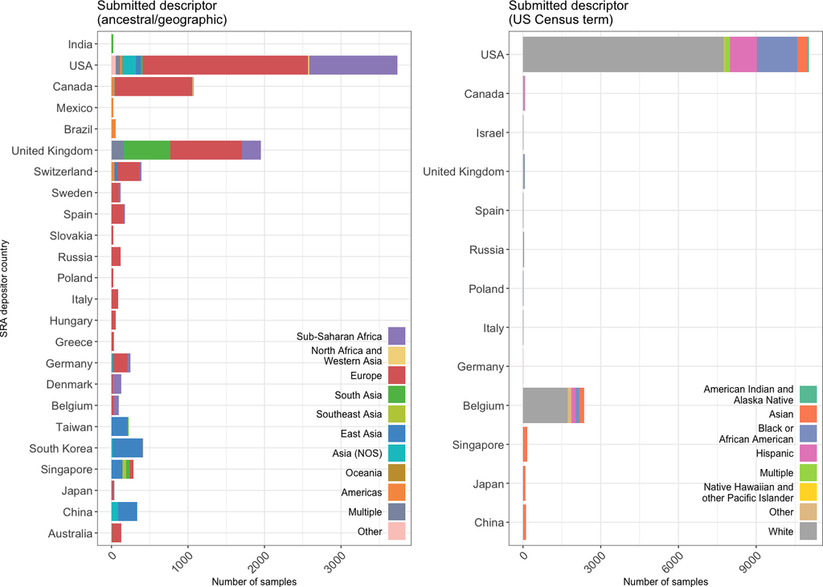

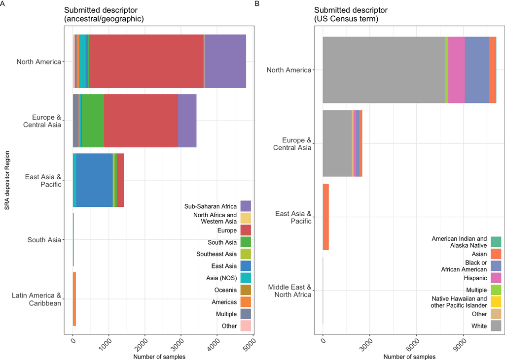

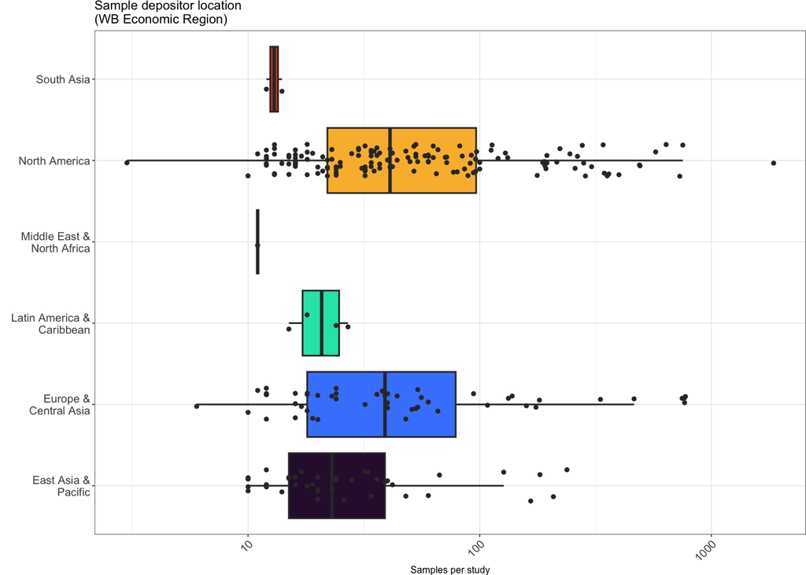

Some nice statistics about all of this:

```r
# By study by world region:
geographyClean %>% group_by(worldRegion, SRA.Study) %>%
  summarise(size = n(), studyGeo = n_distinct(strictestGeography)) %>%
  summarise(n = n(), meanSize = mean(size), meanGeo = mean(studyGeo), maxSize = max(size), maxGeo = max(studyGeo), sdSize = sd(size), sdGeo = sd(studyGeo))
```

```
## # A tibble: 6 × 8
##   worldRegion                      n meanSize meanGeo maxSize maxGeo sdSize sdGeo
##   <chr>                        <int>    <dbl>   <dbl>   <int>  <int>  <dbl> <dbl>
## 1 "East Asia &\nPacific"          29     49.0    1.34     238      5  60.6  0.974
## 2 "Europe &\nCentral Asia"        39     88.1    1.41     748      4 142.   0.818
## 3 "Latin America &\nCaribbean"     4     21      1         27      1   5.48 0
## 4 "North America"                 51     94.3    2.16     753      6 156.   1.43
## 5 "South Asia"                     2     13      2         14      3   1.41 1.41
## 6  <NA>                            2     16      1         18      1   2.83 0
```

```r
raceClean %>% group_by(worldRegion, SRA.Study) %>%
  summarise(size = n(), studyRace = n_distinct(strictestRace)) %>%
  summarise(n = n(), meanSize = mean(size), meanRace = mean(studyRace), maxSize = max(size), maxRace = max(studyRace), sdSize = sd(size), sdRace = sd(studyRace))
```

```
## # A tibble: 4 × 8
##   worldRegion                       n meanSize meanRace maxSize maxRace sdSize sdRace
##   <chr>                         <int>    <dbl>    <dbl>   <int>   <int>  <dbl>  <dbl>
## 1 "East Asia &\nPacific"           13     29.1     1.38     166       4   42.2  0.870
## 2 "Europe &\nCentral Asia"         13    193.      2.46     772       5  328.   1.51
## 3 "Middle East &\nNorth Africa"     1     11       1         11       1   NA   NA
## 4 "North America"                 101    110.      2.49    1857       8  216.   1.49
```

```r
# By descriptor by economic region
geographyClean %>% group_by(SRA.Study, worldRegion) %>% count(strictestGeography) %>% group_by(worldRegion, strictestGeography) %>%
  summarise(size = sum(n), studyGeo = n_distinct(SRA.Study), mean = mean(n), max = max(n), sd = sd(n)) %>%
  as.data.frame()
```

```
##                   worldRegion             strictestGeography size studyGeo       mean max          sd
## 1        East Asia &\nPacific             Sub-Saharan Africa    9        2   4.500000   8   4.9497475
## 2        East Asia &\nPacific North Africa and\nWestern Asia    3        1   3.000000   3          NA
## 3        East Asia &\nPacific                         Europe  190        7  27.142857  61  20.5298853
## 4        East Asia &\nPacific                     South Asia   60        3  20.000000  44  21.6333077
## 5        East Asia &\nPacific                 Southeast Asia   49        2  24.500000  48  33.2340187
## 6        East Asia &\nPacific                      East Asia 1009       20  50.450000 208  62.0708212
## 7        East Asia &\nPacific                     Asia (NOS)  100        4  25.000000  39  13.4907376
## 8      Europe &\nCentral Asia             Sub-Saharan Africa  516       10  51.600000 129  42.8205558
## 9      Europe &\nCentral Asia                         Europe 2048       31  66.064516 375  92.4279667
## 10     Europe &\nCentral Asia                     South Asia  611        5 122.200000 365 148.2588952
## 11     Europe &\nCentral Asia                      East Asia   40        1  40.000000  40          NA
## 12     Europe &\nCentral Asia                     Asia (NOS)   23        3   7.666667  18   9.0737717
## 13     Europe &\nCentral Asia                       Americas   40        2  20.000000  39  26.8700577
## 14     Europe &\nCentral Asia                       Multiple  153        1 153.000000 153          NA
```

[output cut: 16 more lines]

```r
raceClean %>% group_by(SRA.Study, worldRegion) %>% count(strictestRace) %>% group_by(worldRegion, strictestRace) %>%
  summarise(size = sum(n), studyRace = n_distinct(SRA.Study), mean = mean(n), max = max(n), sd = sd(n)) %>%
  as.data.frame()
```

```
##                    worldRegion                               strictestRace size studyRace       mean  max         sd
## 1         East Asia &\nPacific          American Indian and\nAlaska Native    3         1   3.000000    3         NA
## 2         East Asia &\nPacific                                       Asian  330        10  33.000000  164  46.640469
## 3         East Asia &\nPacific                  Black or\nAfrican American    2         1   2.000000    2         NA
## 4         East Asia &\nPacific                                    Hispanic   14         2   7.000000   12   7.071068
## 5         East Asia &\nPacific                                       White   29         4   7.250000   13   5.123475
## 6       Europe &\nCentral Asia          American Indian and\nAlaska Native    3         1   3.000000    3         NA
## 7       Europe &\nCentral Asia                                       Asian  194         4  48.500000   96  54.848276
## 8       Europe &\nCentral Asia                  Black or\nAfrican American  174         8  21.750000   80  26.665923
## 9       Europe &\nCentral Asia                                    Hispanic  167         5  33.400000   96  37.825917
## 10      Europe &\nCentral Asia                                       Other  142         3  47.333333   64  17.009801
## 11      Europe &\nCentral Asia                                       White 1832        11 166.545455  630 251.887421
## 12 Middle East &\nNorth Africa                                       White   11         1  11.000000   11         NA
## 13               North America          American Indian and\nAlaska Native   39         9   4.333333   18   5.722762
## 14               North America                                       Asian  412        32  12.875000   55  13.689530
## 15               North America                  Black or\nAfrican American 1556        62  25.096774  177  32.137364
## 16               North America                                    Hispanic 1066        40  26.650000  562  88.227721
## 17               North America                                    Multiple  203        13  15.615385   49  16.545586
## 18               North America Native Hawaiian and\nother Pacific Islander    6         3   2.000000    3   1.000000
## 19               North America                                       Other   20         8   2.500000    5   1.309307
## 20               North America                                       White 7797        84  92.821429 1005 154.517918
```

```r
allSRAFinal %>% filter(!is.na(worldBank)) %>% count(worldBank) %>% mutate(freq = n/sum(n)) %>% arrange(desc(freq))
```

```
##             worldBank     n       freq
## 1         High income 23212 0.97648395
## 2 Upper middle income   533 0.02242228
## 3 Lower middle income    26 0.00109377
```

```r
allSRAFinal %>% filter(!is.na(finalCountry)) %>% count(finalCountry) %>% mutate(freq = n/sum(n)) %>% arrange(desc(freq))
```

```
##      finalCountry     n         freq
## 1             USA 14762 0.6210087922
## 2         Belgium  2455 0.1032771024
## 3  United Kingdom  2018 0.0848933575
## 4          Canada  1144 0.0481258677
## 5       Singapore   452 0.0190147659
## 6           China   449 0.0188885617
## 7     South Korea   411 0.0172899752
## 8     Switzerland   388 0.0163224097
## 9         Germany   253 0.0106432207
## 10         Taiwan   222 0.0093391107
## 11          Spain   186 0.0078246603
## 12         Russia   166 0.0069832990
## 13          Japan   139 0.0058474612
## 14      Australia   125 0.0052585083
## 15        Denmark   124 0.0052164402
## 16         Sweden   118 0.0049640318
## 17          Italy    99 0.0041647385
## 18         Brazil    57 0.0023978798
## 19        Hungary    54 0.0022716756
## 20         Poland    34 0.0014303142
## 21         Greece    28 0.0011779059
## 22         Mexico    27 0.0011358378
## 23          India    26 0.0010937697
## 24       Slovakia    23 0.0009675655
## 25         Israel    11 0.0004627487
```

```r
allSRAFinal %>% filter(!is.na(strictestGeography)) %>% count(worldBank) %>% mutate(freq = n/sum(n)) %>% arrange(desc(freq))
```

```
##             worldBank    n        freq
## 1         High income 9325 0.951239417
## 2 Upper middle income  420 0.042844027
## 3                <NA>   32 0.003264307
## 4 Lower middle income   26 0.002652249
```

```r
allSRAFinal %>% filter(!is.na(strictestRace)) %>% count(worldBank) %>% mutate(freq = n/sum(n)) %>% arrange(desc(freq))
```

```
##             worldBank     n        freq
## 1         High income 13887 0.991928571
## 2 Upper middle income   113 0.008071429
```

```r
allSRAFinal %>% filter(!is.na(strictestGeography)) %>% count(finalCountry) %>% mutate(freq = n/sum(n)) %>% arrange(desc(freq))
```

```
##      finalCountry    n        freq
## 1             USA 3735 0.381005815
## 2  United Kingdom 1951 0.199020708
## 3          Canada 1072 0.109354279
## 4     South Korea  411 0.041925941
## 5     Switzerland  388 0.039579720
## 6           China  336 0.034275222
## 7       Singapore  286 0.029174742
## 8         Germany  247 0.025196368
## 9          Taiwan  222 0.022646129
## 10          Spain  174 0.017749668
## 11      Australia  125 0.012751199
## 12        Denmark  124 0.012649189
## 13         Russia  118 0.012037131
## 14         Sweden  118 0.012037131
## 15        Belgium   98 0.009996940
## 16          Italy   87 0.008874834
## 17         Brazil   57 0.005814547
## 18        Hungary   54 0.005508518
## 19          Japan   40 0.004080384
## 20           <NA>   32 0.003264307
## 21         Greece   28 0.002856268
## 22         Mexico   27 0.002754259
## 23          India   26 0.002652249
## 24         Poland   24 0.002448230
## 25       Slovakia   23 0.002346221
```

```r
allSRAFinal %>% filter(!is.na(strictestRace)) %>% count(finalCountry) %>% mutate(freq = n/sum(n)) %>% arrange(desc(freq))
```

```
##      finalCountry     n         freq
## 1             USA 11027 0.7876428571
## 2         Belgium  2357 0.1683571429
## 3       Singapore   166 0.0118571429
## 4           China   113 0.0080714286
## 5           Japan    99 0.0070714286
## 6          Canada    72 0.0051428571
## 7  United Kingdom    67 0.0047857143
## 8          Russia    48 0.0034285714
## 9           Italy    12 0.0008571429
## 10          Spain    12 0.0008571429
## 11         Israel    11 0.0007857143
## 12         Poland    10 0.0007142857
## 13        Germany     6 0.0004285714
```

```r
allSRAFinal %>% filter(!is.na(strictestGeography)) %>% count(worldRegion) %>% mutate(freq = n/sum(n)) %>% arrange(desc(freq))
```

```
##                  worldRegion    n        freq
## 1              North America 4807 0.490360094
## 2     Europe &\nCentral Asia 3434 0.350300928
## 3       East Asia &\nPacific 1420 0.144853616
## 4 Latin America &\nCaribbean   84 0.008568805
## 5                       <NA>   32 0.003264307
## 6                 South Asia   26 0.002652249
```

```r
allSRAFinal %>% filter(!is.na(strictestRace)) %>% count(worldRegion) %>% mutate(freq = n/sum(n)) %>% arrange(desc(freq))
```

```
##                   worldRegion     n         freq
## 1               North America 11099 0.7927857143
## 2      Europe &\nCentral Asia  2512 0.1794285714
## 3        East Asia &\nPacific   378 0.0270000000
## 4 Middle East &\nNorth Africa    11 0.0007857143
```

```r
allSRAFinal %>% count(worldRegion) %>% mutate(freq = n/sum(n)) %>% arrange(desc(freq))
```

```
##                   worldRegion     n         freq
## 1               North America 15906 0.6682350964
## 2      Europe &\nCentral Asia  5946 0.2498004453
## 3        East Asia &\nPacific  1798 0.0755366971
## 4  Latin America &\nCaribbean    84 0.0035289669
## 5                        <NA>    32 0.0013443684
## 6                  South Asia    26 0.0010922993
## 7 Middle East &\nNorth Africa    11 0.0004621266
```

```r
# And finally... are studies from certain regions bigger than others?
NAEurSizes <- allSRAFinal %>% filter(worldRegion == "North America" | worldRegion == "Europe") %>%
  count(SRA.Study)

restWorldSizes <- allSRAFinal %>% filter(worldRegion != "North America" & worldRegion != "Europe") %>%
  count(SRA.Study)

t.test(restWorldSizes$n, NAEurSizes$n)
```

```
##
##  Welch Two Sample t-test
##
## data:  restWorldSizes$n and NAEurSizes$n
## t = -1.3714, df = 236.84, p-value = 0.1716
## alternative hypothesis: true difference in means is not equal to 0
## 95 percent confidence interval:
##  -77.44803  13.87539
## sample estimates:
## mean of x mean of y
##  79.44444 111.23077
```

```r
allStudySizes <- allSRAFinal %>% group_by(SRA.Study) %>%
  summarise(sampleSize = n(), region = worldRegion) %>%
  distinct()
lm(sampleSize ~ region, data = allStudySizes)
```

```
##
## Call:
## lm(formula = sampleSize ~ region, data = allStudySizes)
##
## Coefficients:
##                       (Intercept)       regionEurope &\nCentral Asia   regionLatin America &\nCaribbean  regionMiddle East &\nNorth Africa                regionNorth America
##                             43.85                              72.73                             -22.85                             -32.85                              67.38
##                  regionSouth Asia
##                            -30.85
```

```r
anova(lm(sampleSize ~ region, data = allStudySizes))
```

```
## Analysis of Variance Table
##
## Response: sampleSize
##            Df  Sum Sq Mean Sq F value Pr(>F)
## region      5  208582   41716   1.214 0.3032
## Residuals 236 8109675   34363
```

Maybe worth considering some alluvial plots? At the single country level they’re very messy, however, so what about at the World Bank region level?

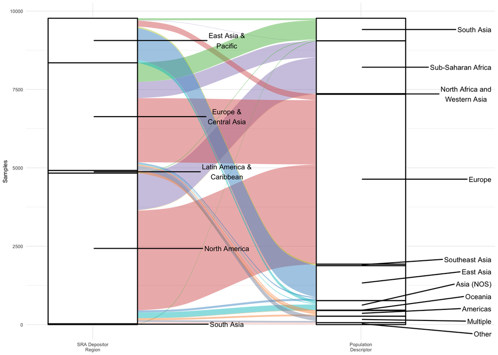

```r
allSRAFinal %>% count(strictestGeography, worldRegion) %>% drop_na(c(strictestGeography, worldRegion)) %>%
  ggplot(data = .,
         aes(axis1 = worldRegion, axis2 = strictestGeography, y = n)) +
    scale_x_discrete(limits = c("SRA Depositor\nRegion", "Population\nDescriptor"), expand = c(.2, .05)) +
    geom_alluvium(aes(fill = strictestGeography)) +
    scale_fill_geography(name="Population\nDescriptor") +
    geom_stratum(width=1/3) +
    ylab("Samples") +
    geom_text_repel(stat = "stratum", aes(label = after_stat(stratum)), size = 2.5, direction = "y", nudge_x = .5) +
    theme_minimal(base_size = 6) +
    theme(legend.position = "none")
```

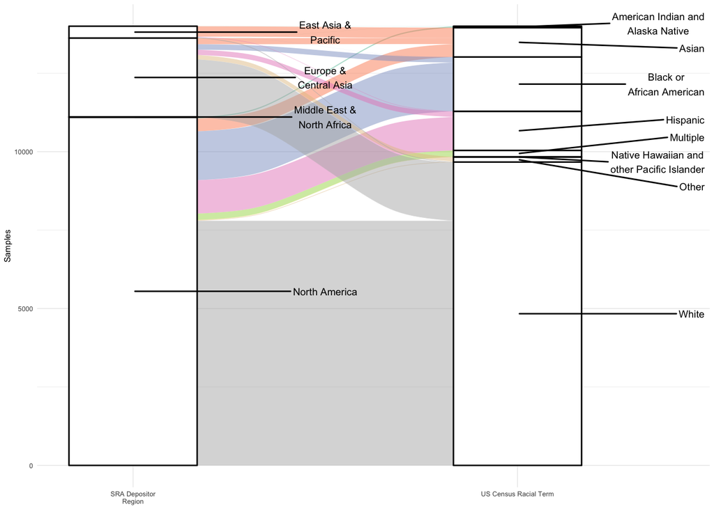

```r
allSRAFinal %>% count(strictestRace, worldRegion) %>% drop_na(c(strictestRace, worldRegion)) %>%
  ggplot(data = .,
         aes(axis1 = worldRegion, axis2 = strictestRace, y = n)) +
    scale_x_discrete(limits = c("SRA Depositor\nRegion", "US Census Racial Term"), expand = c(.2, .05)) +
    geom_alluvium(aes(fill = strictestRace)) +
    scale_fill_race(name="US Census\nTerm)") +
    geom_stratum(width=1/3) +
    ylab("Samples") +
    # geom_text(stat = "stratum", aes(label = after_stat(stratum))) +
    geom_text_repel(stat = "stratum", aes(label = after_stat(stratum)), size = 2.5, direction = "y", nudge_x = .5) +
    theme_minimal(base_size = 6) +
    theme(legend.position = "none")
```

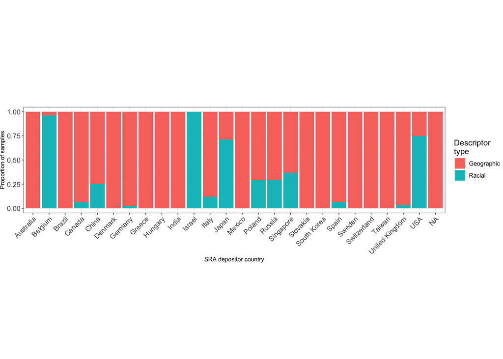

```r
### And finally... does it have any kind of description??
allSRAFinal <- allSRAFinal %>%
  mutate(hasDescriptor = if_else(is.na(strictestRace), "Geographic", "Racial"))

# Easiest to see with a boxplot?
descriptorUsePlot <- ggplot(allSRAFinal, aes(x = finalCountry, fill = hasDescriptor)) +
  geom_bar(position = "fill") +
  ggtitle("") +
  xlab("SRA depositor country") +
  ylab("Proportion of samples") +
  coord_fixed(ratio=6) +
  guides(fill=guide_legend(title="Descriptor\ntype")) +
  theme(axis.text.x = element_text(angle = 45, hjust=1))

descriptorUsePlot
```

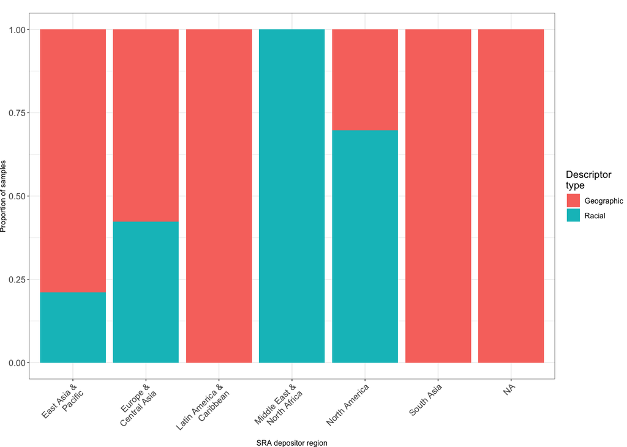

```r
ggsave("fig2_descriptor_use.pdf")
descriptorUseRegionPlot <- ggplot(allSRAFinal, aes(x = worldRegion, fill = hasDescriptor)) +
  geom_bar(position = "fill") +
  ggtitle("") +
  xlab("SRA depositor region") +
  ylab("Proportion of samples") +
  guides(fill=guide_legend(title="Descriptor\ntype")) +
  theme(axis.text.x = element_text(angle = 45, hjust=1))

descriptorUseRegionPlot
```

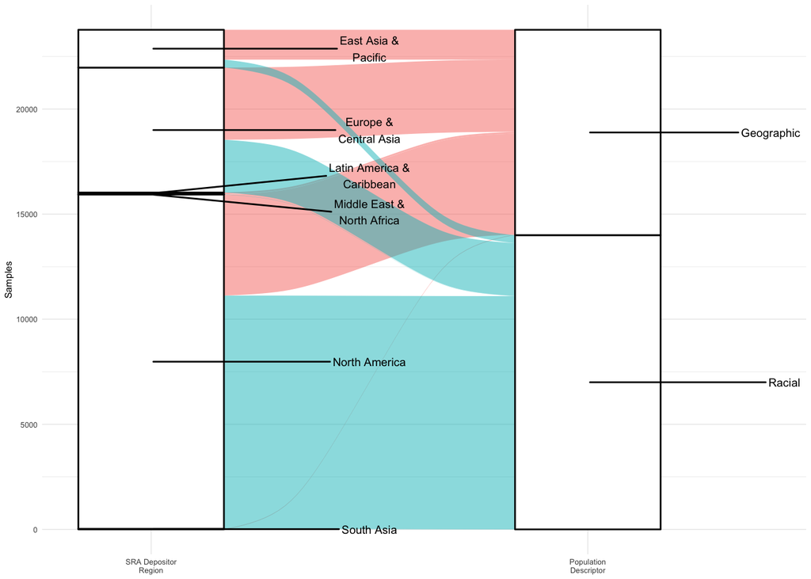

```r
ggsave("fig2_descriptor_use_region_plot.pdf")
descriptorUseRegionAlluvial <- allSRAFinal %>% count(hasDescriptor, worldRegion) %>% drop_na(c(hasDescriptor, worldRegion)) %>%
  ggplot(data = .,
         aes(axis1 = worldRegion, axis2 = hasDescriptor, y = n)) +
    scale_x_discrete(limits = c("SRA Depositor\nRegion", "Population\nDescriptor"), expand = c(.2, .05)) +
    geom_alluvium(aes(fill = hasDescriptor)) +
    geom_stratum(width=1/3) +
    ylab("Samples") +
    geom_text_repel(stat = "stratum", aes(label = after_stat(stratum)), size = 2.5, direction = "y", nudge_x = .5) +
    theme_minimal(base_size = 6) +
    theme(legend.position = "none")

descriptorUseRegionAlluvial
```

```r
ggsave("fig2_descriptor_use_region_alluvial.pdf")
```

And now, some statistics from the figures above:

```r
allSRAFinal %>% count(finalCountry, hasDescriptor) %>%
  group_by(finalCountry) %>%
  mutate(percent = 100 * n/sum(n)) %>%
  ungroup %>%
  as.data.frame()
```

```
##      finalCountry hasDescriptor     n    percent
## 1       Australia    Geographic   125 100.000000
## 2         Belgium    Geographic    98   3.991853
## 3         Belgium        Racial  2357  96.008147
## 4          Brazil    Geographic    57 100.000000
## 5          Canada    Geographic  1072  93.706294
## 6          Canada        Racial    72   6.293706
## 7           China    Geographic   336  74.832962
## 8           China        Racial   113  25.167038
## 9         Denmark    Geographic   124 100.000000
## 10        Germany    Geographic   247  97.628458
## 11        Germany        Racial     6   2.371542
## 12         Greece    Geographic    28 100.000000
## 13        Hungary    Geographic    54 100.000000
## 14          India    Geographic    26 100.000000
```

[output cut: 24 more lines]

```r
allSRAFinal %>% filter(!grepl('USA', finalCountry)) %>%
  count(hasDescriptor) %>%
  mutate(freq = n/sum(n))
```

```
##   hasDescriptor    n      freq
## 1    Geographic 6068 0.6711647
## 2        Racial 2973 0.3288353
```

```r
allSRAFinal %>% filter(grepl('USA', finalCountry)) %>%
  count(hasDescriptor) %>%
  mutate(freq = n/sum(n))
```

```
##   hasDescriptor     n      freq
## 1    Geographic  3735 0.2530145
## 2        Racial 11027 0.7469855
```

```r
descriptorChi <- full_join((allSRAFinal %>% filter(!grepl('USA', finalCountry)) %>%
  count(hasDescriptor) %>%
  mutate(freq = n/sum(n))),
  (allSRAFinal %>% filter(grepl('USA', finalCountry)) %>%
  count(hasDescriptor) %>%
  mutate(freq = n/sum(n))), by = "hasDescriptor", suffix = c("noUSA", "USA"))

# Test the numbers:
chisq.test(descriptorChi[,c(2,4)])
```

```
##
##  Pearson's Chi-squared test with Yates' continuity correction
##
## data:  descriptorChi[, c(2, 4)]
## X-squared = 4045.6, df = 1, p-value < 2.2e-16
```

```r
fisher.test(descriptorChi[,c(2,4)]) # Odds ratio interpretation varies depending on order, but otherwise all good.
```

```
##
##  Fisher's Exact Test for Count Data
##
## data:  descriptorChi[, c(2, 4)]
## p-value < 2.2e-16
## alternative hypothesis: true odds ratio is not equal to 1
## 95 percent confidence interval:
##  5.686497 6.385844
## sample estimates:
## odds ratio
##   6.025321
```

```r
# We also want to know the mean sample size of studies in the USA vs those not in the USA, for funsies
usaSizes <- allSRAFinal %>% filter(grepl('USA', finalCountry)) %>%
  group_by(SRA.Study) %>%
  summarise(n = n())
mean(usaSizes$n)
```

```
## [1] 110.9925
```

```r
nousaSizes <- allSRAFinal %>% filter(!grepl('USA', finalCountry)) %>%
  group_by(SRA.Study) %>%
  summarise(n = n())
mean(nousaSizes$n)
```

```
## [1] 81.45045
```

```r
t.test(usaSizes$n, nousaSizes$n)
```

```
##
##  Welch Two Sample t-test
##
## data:  usaSizes$n and nousaSizes$n
## t = 1.2665, df = 241.72, p-value = 0.2065
## alternative hypothesis: true difference in means is not equal to 0
## 95 percent confidence interval:
##  -16.40406  75.48812
## sample estimates:
## mean of x mean of y
## 110.99248  81.45045
```

And now the overrepresentation stats using the population data too:

```r
sraCountry <- allSRAFinal %>% drop_na(finalCountry) %>%
  count(finalCountry, worldRegion, worldBank) %>%
  melt() %>%
  arrange(worldRegion) %>%
  mutate(db = "SRA") %>%
  mutate(finalCountry = ifelse(grepl("USA", finalCountry), "United States", finalCountry))
worldPop <- read.csv("RNA-seq-diversity_world-population.csv")
worldPop$name <- gsub("Korea, South", "South Korea", worldPop$name)

sraCountry2 <- sraCountry %>%
  group_by(finalCountry, db, worldRegion) %>%
  summarise(value = sum(value)) %>%
  as.data.frame()
```

```r
sraCountry3 <- left_join(sraCountry2, worldPop, join_by( "finalCountry" == "name"))

# And now we get some fancy new columns for plotting
sraCountry3 <- sraCountry3 %>%
  mutate(fractPop = value.y/sum(worldPop$value)) %>%
  group_by(db) %>%
  mutate(fractDB = value.x/sum(value.x)) %>%
  mutate(excess = fractDB/fractPop) %>%
  as.data.frame()

# How many samples have a country
allSRAFinal %>% count(is.na(finalCountry))
```

```
##   is.na(finalCountry)     n
## 1               FALSE 23771
## 2                TRUE    32
```

```r
# How many institutions?
allSRAFinal %>% drop_na(finalCountry) %>% summarise(studies = n_distinct(SRA.Study), countries = n_distinct(finalCountry))
```

```
##   studies countries
## 1     242        25
```

```r
# Overrepresentation of submitting country relative to global population:
sraCountry3
```

```
##      finalCountry  db                 worldRegion value.x    value.y                  region     fractPop      fractDB       excess
## 1       Australia SRA        East Asia &\nPacific     125   26768598   Australia and Oceania 0.0033222983 0.0052585083  1.582792327
## 2         Belgium SRA      Europe &\nCentral Asia    2455   11977634                  Europe 0.0014865655 0.1032771024 69.473632510
## 3          Brazil SRA  Latin America &\nCaribbean      57  220051512           South America 0.0273109845 0.0023978798  0.087799097
## 4          Canada SRA               North America    1144   38794813           North America 0.0048148932 0.0481258677  9.995209710
## 5           China SRA        East Asia &\nPacific     449 1416043270 East and Southeast Asia 0.1757476487 0.0188885617  0.107475473
## 6         Denmark SRA      Europe &\nCentral Asia     124    5973136                  Europe 0.0007413365 0.0052164402  7.036534654
## 7         Germany SRA      Europe &\nCentral Asia     253   84119100                  Europe 0.0104401711 0.0106432207  1.019448879
## 8          Greece SRA      Europe &\nCentral Asia      28   10461091                  Europe 0.0012983446 0.0011779059  0.907236679
## 9         Hungary SRA      Europe &\nCentral Asia      54    9855745                  Europe 0.0012232140 0.0022716756  1.857136605
## 10          India SRA                  South Asia      26 1409128296              South Asia 0.1748894190 0.0010937697  0.006254065
## 11         Israel SRA Middle East &\nNorth Africa      11    9402617             Middle East 0.0011669755 0.0004627487  0.396536791
## 12          Italy SRA      Europe &\nCentral Asia      99   60964931                  Europe 0.0075664660 0.0041647385  0.550420571
## 13          Japan SRA        East Asia &\nPacific     139  123201945 East and Southeast Asia 0.0152908125 0.0058474612  0.382416643
## 14         Mexico SRA  Latin America &\nCaribbean      27  130739927           North America 0.0162263649 0.0011358378  0.069999522
## 15         Poland SRA      Europe &\nCentral Asia      34   38746310                  Europe 0.0048088734 0.0014303142  0.297432292
## 16         Russia SRA      Europe &\nCentral Asia     166  140820810            Central Asia 0.0174775212 0.0069832990  0.399558891
## 17      Singapore SRA        East Asia &\nPacific     452    6028459 East and Southeast Asia 0.0007482028 0.0190147659 25.413920795
## 18       Slovakia SRA      Europe &\nCentral Asia      23    5563649                  Europe 0.0006905144 0.0009675655  1.401224304
## 19    South Korea SRA        East Asia &\nPacific     411   52081799 East and Southeast Asia 0.0064639647 0.0172899752  2.674825123
## 20          Spain SRA      Europe &\nCentral Asia     186   47280433                  Europe 0.0058680586 0.0078246603  1.333432536
## 21         Sweden SRA      Europe &\nCentral Asia     118   10589835                  Europe 0.0013143233 0.0049640318  3.776872836
## 22    Switzerland SRA      Europe &\nCentral Asia     388    8860574                  Europe 0.0010997016 0.0163224097 14.842580651
## 23         Taiwan SRA        East Asia &\nPacific     222   23595274 East and Southeast Asia 0.0029284514 0.0093391107  3.189095306
## 24 United Kingdom SRA      Europe &\nCentral Asia    2018   68459055                  Europe 0.0084965751 0.0848933575  9.991479711
## 25  United States SRA               North America   14762  341963408           North America 0.0424416868 0.6210087922 14.632047868
```

```r
# We wanna test the USA, so:
usaSamples <- allSRAFinal %>% filter(finalCountry == "United States") %>% nrow()
allSamples <- allSRAFinal %>% drop_na(finalCountry) %>% nrow()
usaProp <- sraCountry3[sraCountry3$finalCountry %in% "United States", ]$fractPop[1]

# And finally, a binomial test for the USA
binom.test(usaSamples, allSamples, usaProp)
```

```
##
##  Exact binomial test
##
## data:  usaSamples and allSamples
## number of successes = 0, number of trials = 23771, p-value < 2.2e-16
## alternative hypothesis: true probability of success is not equal to 0.04244169
## 95 percent confidence interval:
##  0.000000000 0.000155172
## sample estimates:
## probability of success
##                      0
```

```r
# And another one for institutions in LATAM + Caribbean
latamSamples <- sraCountry3 %>% filter(worldRegion == "Latin America &\nCaribbean") %>%
  summarise(samples = sum(value.x)) %>%
  mutate(proportion = samples/allSamples)

# But to do the test we need to know how many people live in LATAM...
latamProp <- worldPop %>% filter(region %in% c("Central America and the Caribbean", "South America")) %>% summarise(sum(value))/sum(worldPop$value)

binom.test(latamSamples$samples, allSamples, latamProp[1,1])
```

```
##
##  Exact binomial test
##
## data:  latamSamples$samples and allSamples
## number of successes = 84, number of trials = 23771, p-value < 2.2e-16
## alternative hypothesis: true probability of success is not equal to 0.06654691
## 95 percent confidence interval:
##  0.002819581 0.004373141
## sample estimates:
## probability of success
##            0.003533718
```